# assignment3

2026-09-01

## Hypothesis:

There is no difference in average tire tread depth (TIRETREAD) between top tire manufacturers (TIREMANUF) and all other manufacturers.

## 1) Load CSV

```r
tire_data <- read.csv("tire_data.csv")
#remove missing data
clean_data <- subset(tire_data, TIRETREAD < 90)
summary(tire_data)
```

```
##   source_file        CASEID             PSU            CASENO
##  Min.   :1.000   Min.   :  20282   Min.   :10.00   Min.   :  1.00
##  1st Qu.:2.000   1st Qu.:  25329   1st Qu.:18.00   1st Qu.: 34.00
##  Median :3.000   Median :  30301   Median :26.00   Median : 68.00
##  Mean   :2.745   Mean   : 882262   Mean   :34.07   Mean   : 73.96
##  3rd Qu.:4.000   3rd Qu.:2401844   3rd Qu.:52.00   3rd Qu.:106.00
##  Max.   :4.000   Max.   :2406391   Max.   :82.00   Max.   :259.00
##      CASENUMBER       CATEGORY          VEHNO           TIRELOC
##  Length   :76640   Min.   : 1.000   Min.   :1.00   Length   :76640
##  N.unique :14409   1st Qu.: 3.000   1st Qu.:1.00   N.unique :    4
##  N.blank  :    0   Median : 4.000   Median :1.00   N.blank  :    0
##  Min.nchar:   16   Mean   : 5.096   Mean   :1.41   Min.nchar:    2
##  Max.nchar:   17   3rd Qu.: 7.000   3rd Qu.:2.00   Max.nchar:    2
##                    Max.   :22.000   Max.   :7.00
##    TIREMANUF         TIREMODEL          TIRESIZE          TIRETIN
##  Min.   :  1.0   Length   :76640   Length   :76640   Length   :76640
##  1st Qu.: 59.0   N.unique : 7536   N.unique :  610   N.unique :34699
##  Median :103.0   N.blank  :    0   N.blank  :    0   N.blank  :    0
##  Mean   :277.7   Min.nchar:    2   Min.nchar:    7   Min.nchar:    4
##  3rd Qu.:201.0   Max.nchar:   39   Max.nchar:   14   Max.nchar:   13
##  Max.   :999.0
##    TIRETREAD       TIRERESTR      TIRESIZETYPE     CASEWGT
##  Min.   : 0.00   Min.   :0.000   Min.   :1.00   Min.   :    4.139
##  1st Qu.: 5.00   1st Qu.:0.000   1st Qu.:1.00   1st Qu.:   66.294
##  Median : 6.00   Median :0.000   Median :1.00   Median :  164.057
##  Mean   :21.04   Mean   :0.451   Mean   :2.18   Mean   :  617.972
##  3rd Qu.: 9.00   3rd Qu.:0.000   3rd Qu.:1.00   3rd Qu.:  455.966
##  Max.   :99.00   Max.   :9.000   Max.   :9.00   Max.   :24230.454
##     PSUSTRAT         VERSION
##  Min.   : 1.000   Min.   :6.000
##  1st Qu.: 4.000   1st Qu.:7.000
##  Median : 7.000   Median :8.000
##  Mean   : 6.645   Mean   :7.745
##  3rd Qu.: 9.000   3rd Qu.:9.000
##  Max.   :12.000   Max.   :9.000
```

# Boxplot of Tire Tread Depth vs Tire Location

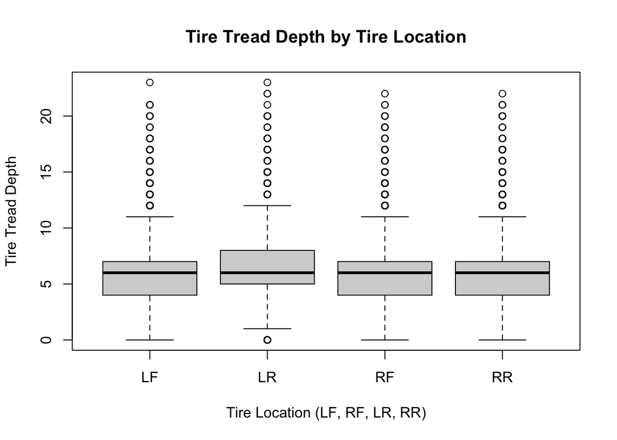

```r
boxplot(TIRETREAD ~ TIRELOC, data = clean_data,
        main = "Tire Tread Depth by Tire Location",
        xlab = "Tire Location (LF, RF, LR, RR)",
        ylab = "Tire Tread Depth")
```

## 2) Statistical Calculations:

# Separate tread depth into Top Manufacturer (70) vs. Other Manufacturers

70 is the the numerical manufacturing code for specific tires. It is the most common frequently occuring manufacturer in my dataset.

```r
top_manuf <- subset(clean_data, TIREMANUF == 70)$TIRETREAD
other_manuf <- subset(clean_data, TIREMANUF != 70)$TIRETREAD
```

# Mean and Standard Deviation calculations

```r
mean_top <- mean(top_manuf)
sd_top <- sd(top_manuf)

mean_other <- mean(other_manuf)
sd_other <- sd(other_manuf)
```

# Print results

```r
cat("Top Manufacturer Mean Tread:", mean_top, "\n")
```

```
## Top Manufacturer Mean Tread: 6.206326
```

```r
cat("Top Manufacturer Std Dev:", sd_top, "\n")
```

```
## Top Manufacturer Std Dev: 2.54403
```

```r
cat("Other Manufacturers Mean Tread:", mean_other, "\n")
```

```
## Other Manufacturers Mean Tread: 6.09485
```

```r
cat("Other Manufacturers Std Dev:", sd_other, "\n")
```

```
## Other Manufacturers Std Dev: 2.467963
```

# Simple barplot comparing means

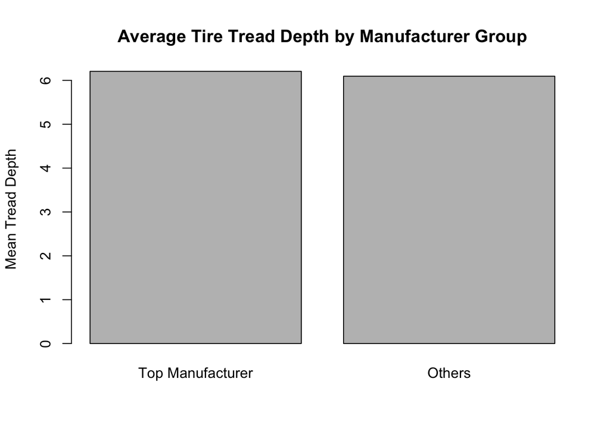

```r
means_vector <- c(mean_top, mean_other)
barplot(means_vector,
        names.arg = c("Top Manufacturer", "Others"),
        main = "Average Tire Tread Depth by Manufacturer Group",
        ylab = "Mean Tread Depth")
```

Explanation: The top manufacturer group has a slightly higher average tread depth (6.21) than all other manufacturers (6.09). This small mean difference of 0.12 units suggests similar average wear levels between the two groups.

## 3) Test 1:

# Correlation test between Tire Size Type and Tire Tread Depth

```r
cor.test(clean_data$TIRESIZETYPE, clean_data$TIRETREAD)
```

```
##
##  Pearson's product-moment correlation
##
## data:  clean_data$TIRESIZETYPE and clean_data$TIRETREAD
## t = 27.864, df = 64317, p-value < 2.2e-16
## alternative hypothesis: true correlation is not equal to 0
## 95 percent confidence interval:
##  0.1015704 0.1168425
## sample estimates:
##       cor
## 0.1092129
```

# Linear Regression Model

```r
model <- lm(TIRETREAD ~ TIRESIZETYPE, data = clean_data)
model_summary <- summary(model)
model_summary
```

```
##
## Call:
## lm(formula = TIRETREAD ~ TIRESIZETYPE, data = clean_data)
##
## Residuals:
##     Min      1Q  Median      3Q     Max
## -9.3939 -2.0533 -0.0533  0.9467 16.9467
##
## Coefficients:
##              Estimate Std. Error t value Pr(>|t|)
## (Intercept)   5.63575    0.01950  289.06   <2e-16 ***
## TIRESIZETYPE  0.41757    0.01499   27.86   <2e-16 ***
## ---
## Signif. codes:  0 '***' 0.001 '**' 0.01 '*' 0.05 '.' 0.1 ' ' 1
##
## Residual standard error: 2.462 on 64317 degrees of freedom
## Multiple R-squared:  0.01193,    Adjusted R-squared:  0.01191
## F-statistic: 776.4 on 1 and 64317 DF,  p-value: < 2.2e-16
```

# Extract R-squared and p-value

```r
r_squared <- model_summary$r.squared
p_val <- model_summary$coefficients[2, 4]

cat("R-squared:", r_squared, "\n")
```

```
## R-squared: 0.01192746
```

```r
cat("p-value:", p_val, "\n")
```

```
## p-value: 7.50917e-170
```